# Red wine exploration by Ada Zamora

I decided to work with the red wine quality dataset (see data set references). This dataset contains 1599 observations with 11 variables on the chemical properties of the wine. At least 3 wine experts rated the quality of each wine, providing a rating between 0 (very bad) and 10 (very excellent), which is the output variable. In this Exploratory Data Analysis I plan to determine which chemical properties influence the quality of red wines.

# Univariate Plots Section

I’ll first run a summary to have an idea of the data, the variables ranges and distribution.

```
##  fixed.acidity   volatile.acidity  citric.acid    residual.sugar
##  Min.   : 4.60   Min.   :0.1200   Min.   :0.000   Min.   : 0.900
##  1st Qu.: 7.10   1st Qu.:0.3900   1st Qu.:0.090   1st Qu.: 1.900
##  Median : 7.90   Median :0.5200   Median :0.260   Median : 2.200
##  Mean   : 8.32   Mean   :0.5278   Mean   :0.271   Mean   : 2.539
##  3rd Qu.: 9.20   3rd Qu.:0.6400   3rd Qu.:0.420   3rd Qu.: 2.600
##  Max.   :15.90   Max.   :1.5800   Max.   :1.000   Max.   :15.500
##    chlorides       free.sulfur.dioxide total.sulfur.dioxide
##  Min.   :0.01200   Min.   : 1.00       Min.   :  6.00
##  1st Qu.:0.07000   1st Qu.: 7.00       1st Qu.: 22.00
##  Median :0.07900   Median :14.00       Median : 38.00
##  Mean   :0.08747   Mean   :15.87       Mean   : 46.47
##  3rd Qu.:0.09000   3rd Qu.:21.00       3rd Qu.: 62.00
##  Max.   :0.61100   Max.   :72.00       Max.   :289.00
##     density             pH          sulphates         alcohol      quality
##  Min.   :0.9901   Min.   :2.740   Min.   :0.3300   Min.   : 8.40   3: 10
##  1st Qu.:0.9956   1st Qu.:3.210   1st Qu.:0.5500   1st Qu.: 9.50   4: 53
##  Median :0.9968   Median :3.310   Median :0.6200   Median :10.20   5:681
##  Mean   :0.9967   Mean   :3.311   Mean   :0.6581   Mean   :10.42   6:638
##  3rd Qu.:0.9978   3rd Qu.:3.400   3rd Qu.:0.7300   3rd Qu.:11.10   7:199
##  Max.   :1.0037   Max.   :4.010   Max.   :2.0000   Max.   :14.90   8: 18
```

The first thing that I notice here is that the range of the wine’s quality goes from 3 to 8 on a scale of 0 to 10. Also, I notice there are few wines of quality 3 or 8. I want to see the distribution of the wines quality in a plot, so that’s what I’ll create next.

**Quality**

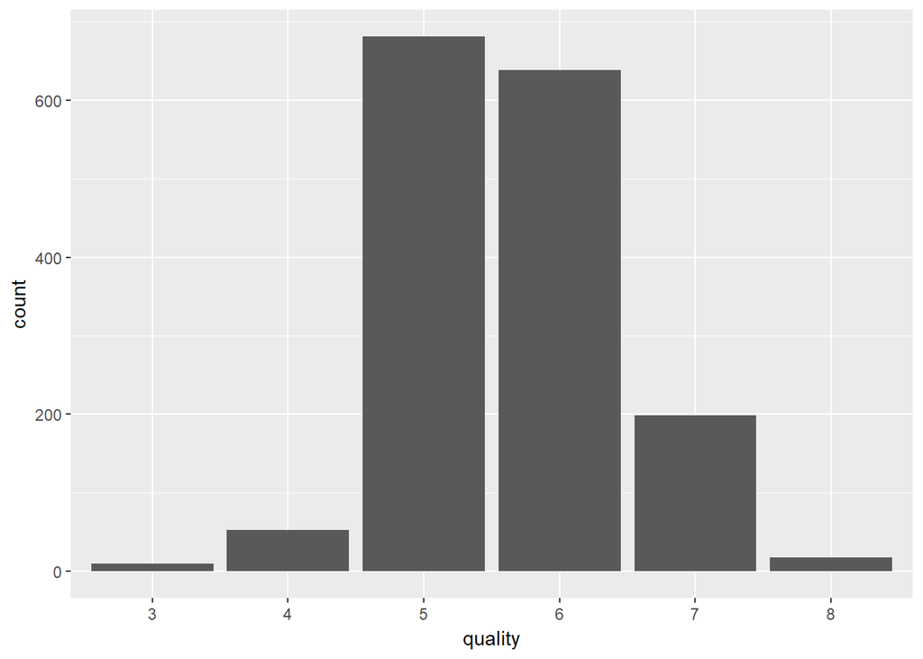

After seeing this distribution, I want to know the exact percentage of wines by quality in the data set.

```
## # A tibble: 6 x 3
##   quality count percentage
##    <fctr> <int>      <dbl>
## 1       3    10  0.6253909
## 2       4    53  3.3145716
## 3       5   681 42.5891182
## 4       6   638 39.8999375
## 5       7   199 12.4452783
## 6       8    18  1.1257036
```

From all the observations in the dataset, 82% of the data has quality 5 or 6. It is also noticeable that the wines could have had a score of 0 to 10 and there’s no wine with a score less than 3 or more than 8.

##### Now I’ll investigate the chemical variables, I’ll create histograms of each variable to have an idea of their distribution

**Alcohol**

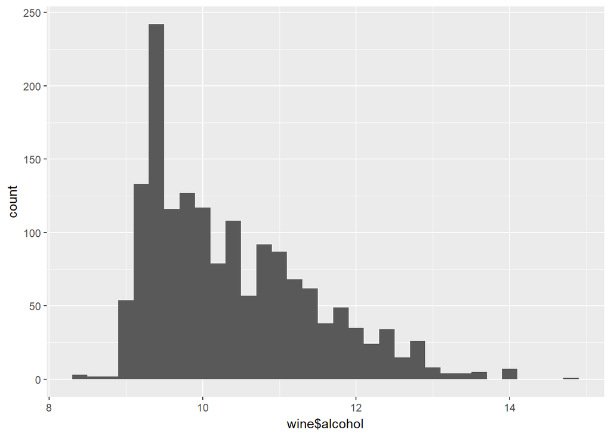

Alcohol level distribution is positevly skewed, and the most common alcohol level is about 9.4 (% by volume)

**Volatile acidity**

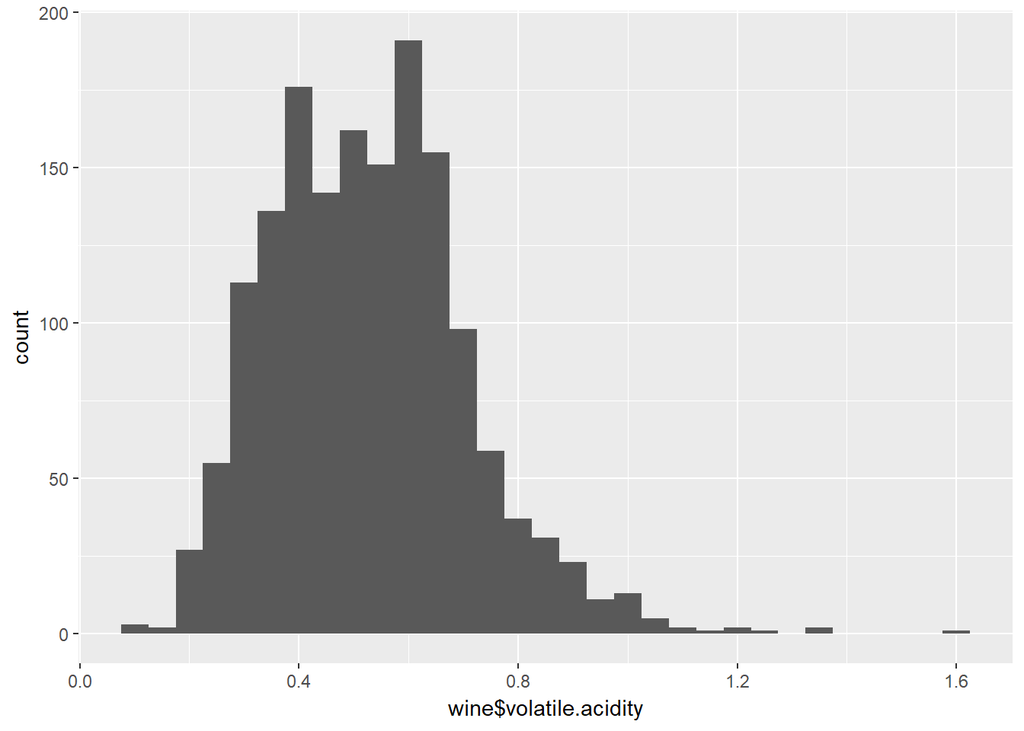

Volatile acidity also presents a positively skewed distribution, this skewed distribution is mainly defined by some outliers in the data.

**Citric acid**

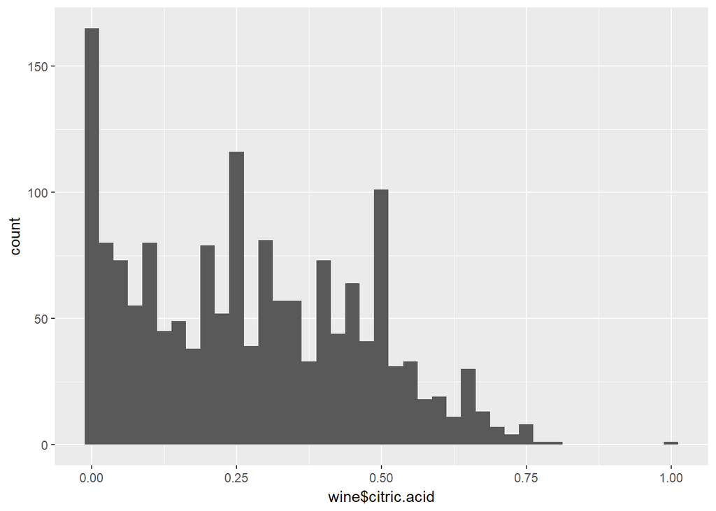

The citric acid distribution does not seem to present a specific pattern as there are three noticeable peaks in the data. The most noticeable peak is at 0 with more than 150 observations, followed by the second one around 0.25 g/dm^3, with more than 100 observations, and the third peak is about 0.50 g/dm^3, with around 100 observations.

**Density**

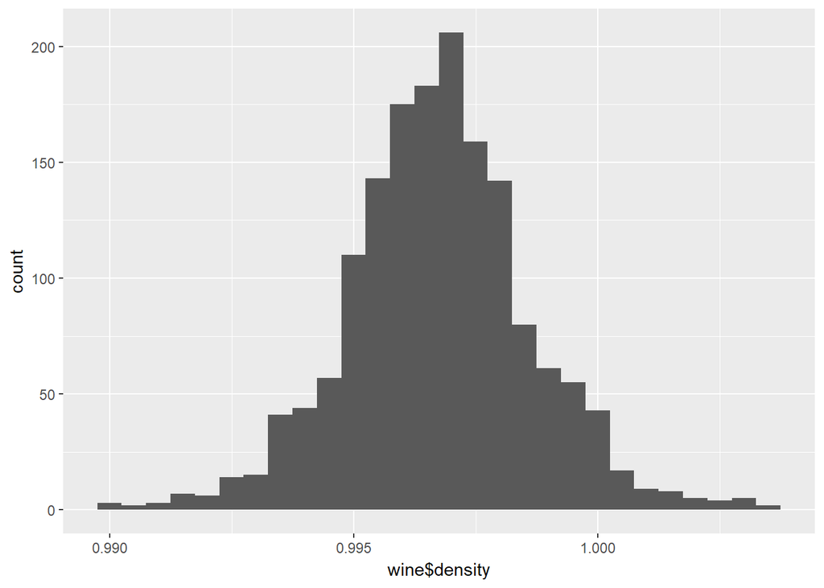

**pH**

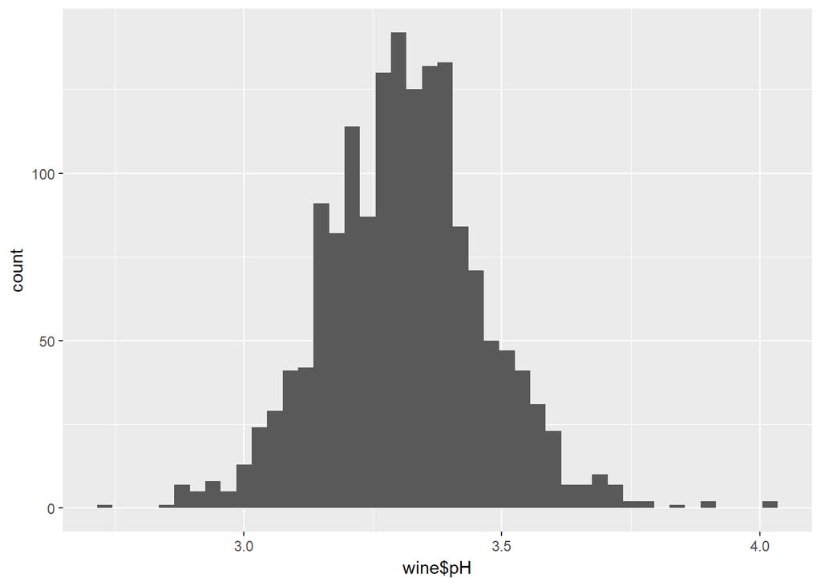

Both density and pH have a normal distrubution.

**Fixed acidity**

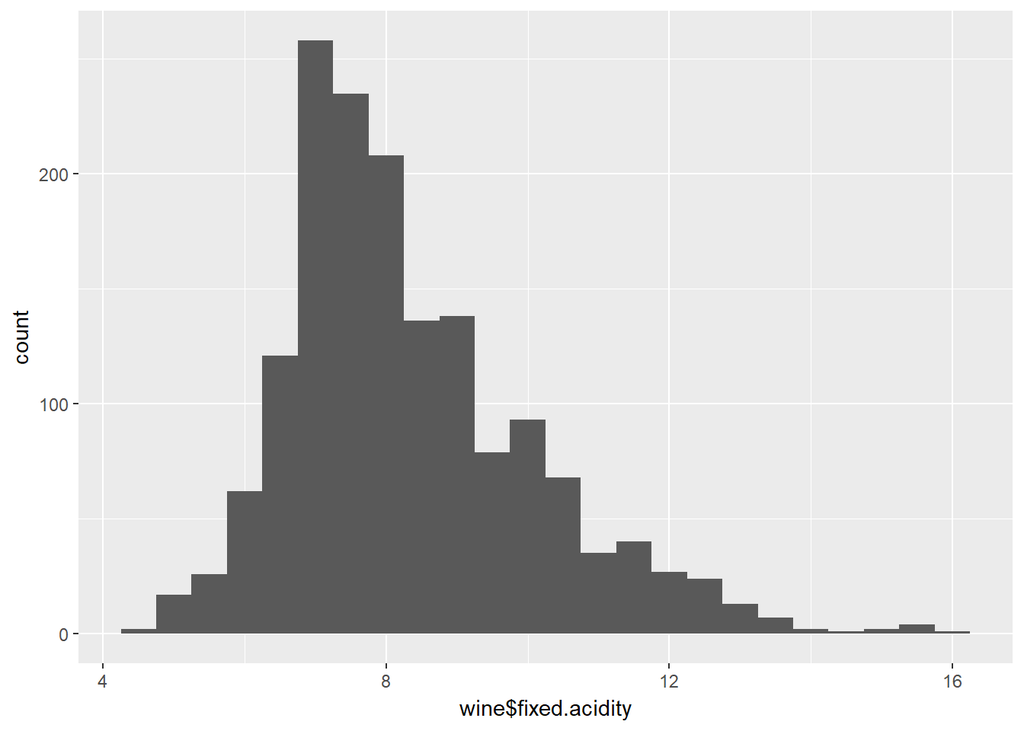

The fixed acidity distribution is positively skewed but does not have a long tail.

In the summary I first created, I see there are several variables with a wide range of values and a mean value closer to the minimum, which makes me believe all of these variables will be positvely skewed. This variables are: residual.sugar, free.sulfur.dioxide, total.sulfur.dioxide and chlorides.

I’ll create histograms of each one of the variables and I’ll group them in one plot

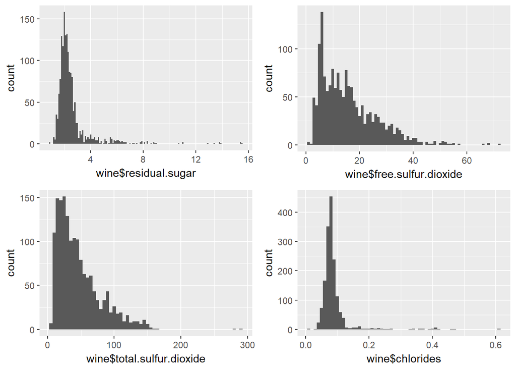

Indeed, all of the above variables present a positiverly skewed dsitribution with long tails. Now I’ll change the x axis scales to have a better idea of the distribution of most part of the data, without the outliers.

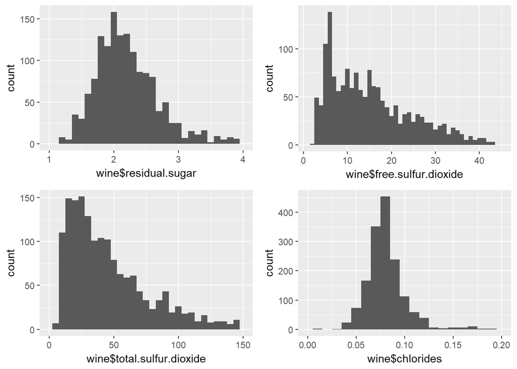

After changing the scales to concentrate in the majority of the data, I see that chlorides and residual sugar have a normal distribution, while free sulfur dioxide has a slightly bimodal distribition and total sulfur dioxide maintains a positevely skewed distribution.

# Univariate Analysis

### What is the structure of your dataset?

There are 1599 observations about red wine quality. Each wine has 11 attributes which are: fixed acidity, volatile acidity, citric acid, residual sugar, chlorides, free sulfur dioxide, total sulfur dioxide, density, pH, sulphates and alcohol. From these attributes, there’s one output variable, which is the quality of the wine: quality.

Other observations:

- 82% of the wine data has a quality of 5 or 6
- 0.6% of the wine data has a quality of 3
- 1.1% of the wine data has a quality of 8

### What is/are the main feature(s) of interest in your dataset?

The main feature of interest in my data set is the quality of the wine. I want to determine the variables that influence the quality of the wine.

### What other features in the dataset do you think will help support your investigation into your feature(s) of interest?

I believe the study of the variables that directly influence the flavour of the wine can help me have a better understanding of the quality of a wine, these variables are:

- Volatile acidity: as if its presentation in a too high level can lead to an unpleasant, vinegar taste
- Citric acid: as it adds freshness and flavor to wines
- Residual sugar: as wines with greater than 45 grams/liter are considered sweet
- Total sulfur dioxide: as in concentrations over 50 ppm is noticeable in the nose and taste of the wine

### Of the features you investigated, were there any unusual distributions? Did you perform any operations on the data to tidy, adjust, or change the form of the data? If so, why did you do this?

The variable citric acid has an unusual distribution which I could not categorize and it presents several peaks, I found three peaks as the most noticeables with the binwidth I selected.

The only operation I performed to the data was to change to factor the vine quality variable and to remove the number of observation row (as R studio already has it and does not count as a row)

# Bivariate Plots Section

First, I’ll create a scatterplot matrix to compare every pair of variables.

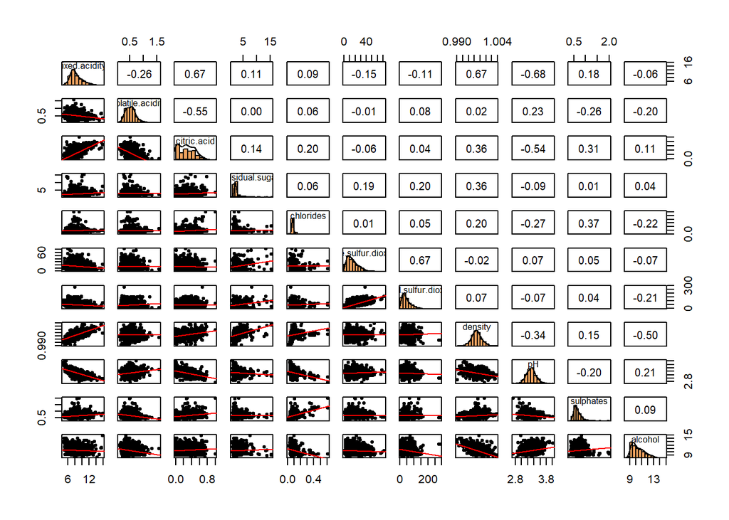

Taking into account these correlations, I’ll plot each one of them to see their distribution:

**Density - Fixed acidity: 0.67**

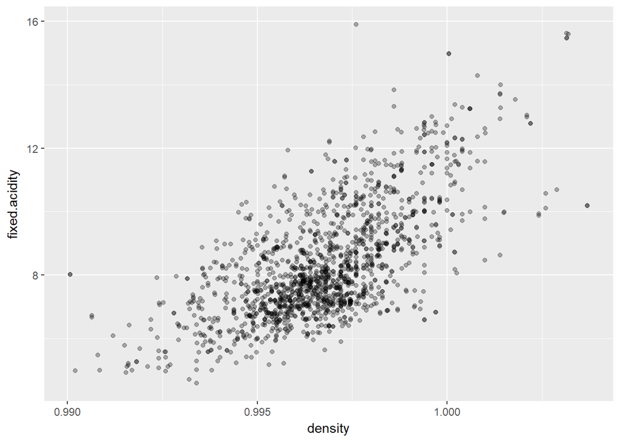

**Fixed acidity - pH: -0.68**

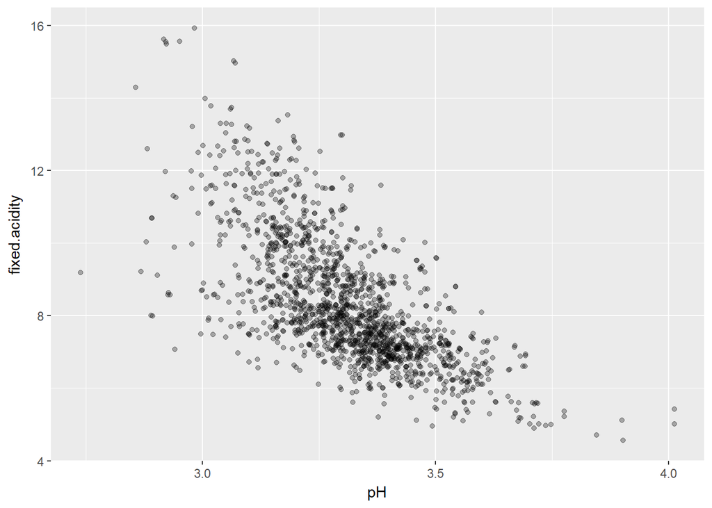

**Citric acid - pH: -0.54**

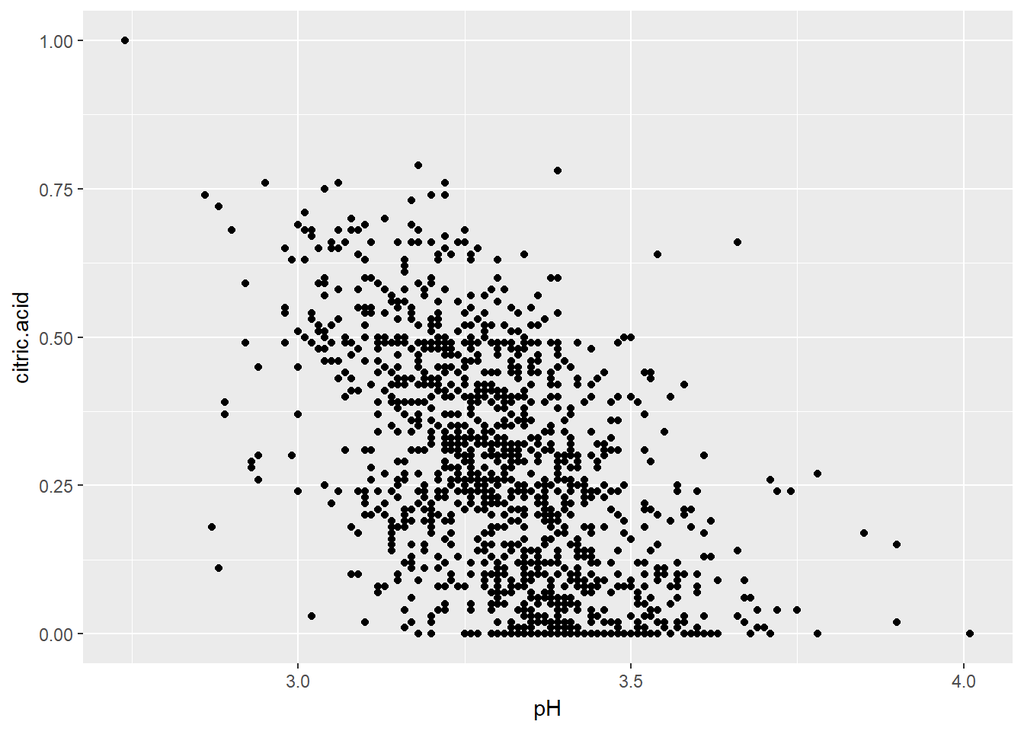

**Free sulfur dioxide - Total sulfur dioxide: 0.67**

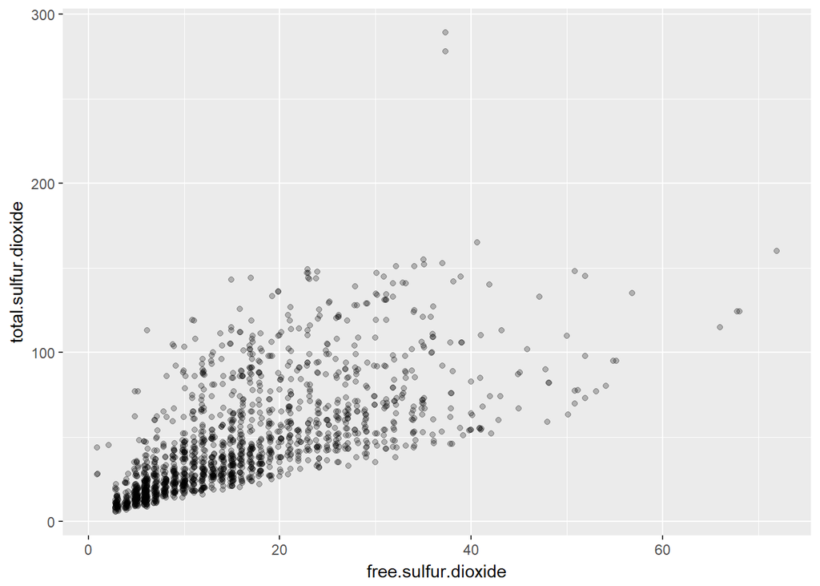

**Alcohol - Density: -0.50**

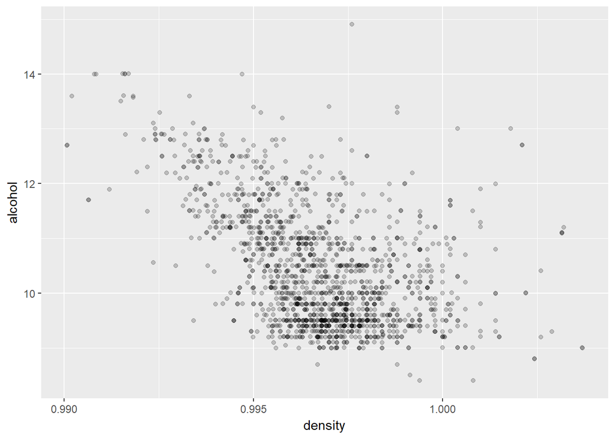

**Citric acid - Volatile acidity: -0.55**

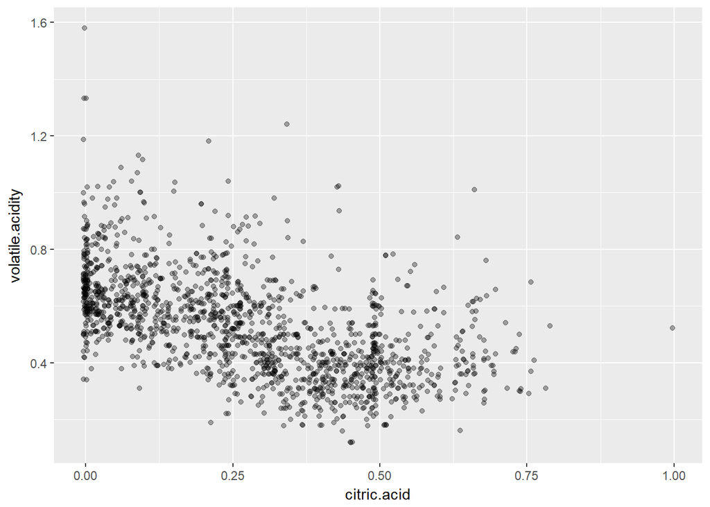

#### Now I want to see the relationship between each one of the variables and the quality of the wine in boxplots

**Fixed acidity**

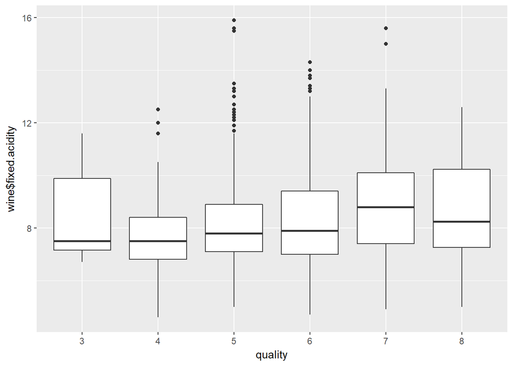

Fixed acidity refers to “most acids involved with wine or fixed or nonvolatile (do not evaporate readily) acidity” (see reference 1)

We can see in the plot that fixed acidity have similar values for all the quality of wines, so it does not seem to be related to the wine’s quality.

**Volatile acidity**

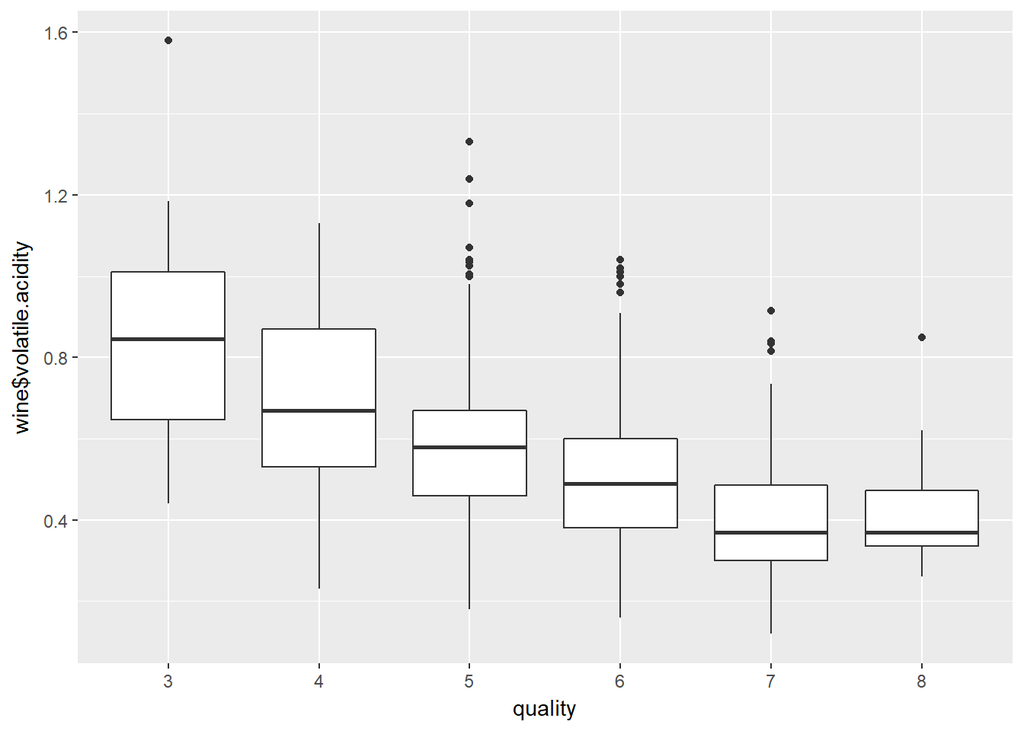

Volatile acidity refers to “the amount of acetic acid in wine, which at too high of levels can lead to an unpleasant, vinegar taste” (see Reference 1)

It can be seen here that better quality wines have lower values of volatile acidity: wines with a quality score of 7 and 8 present the lowest median of volatile acidity. On the other hand, wines of quality 3 tend to have higher values of acetic acid, this can explain their score.

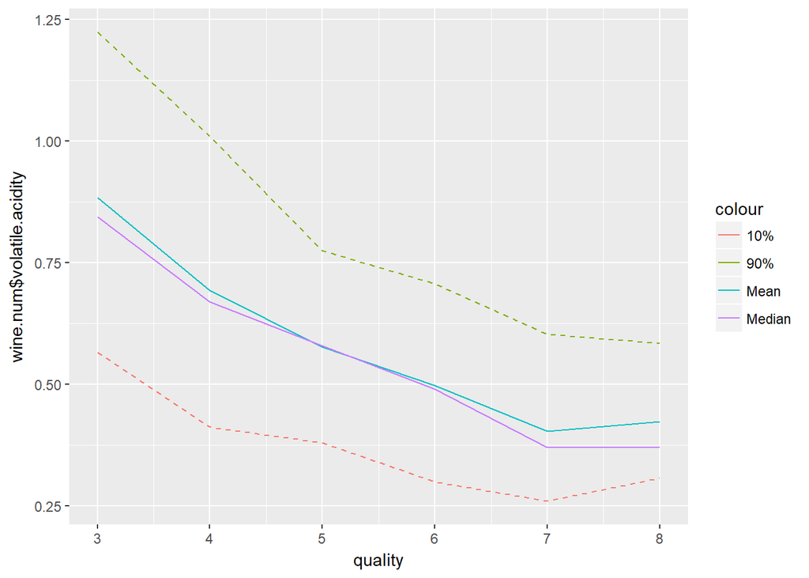

Here we can also see the disminution of volatile acidity as the quality of the wine improves.

**Citric acid**

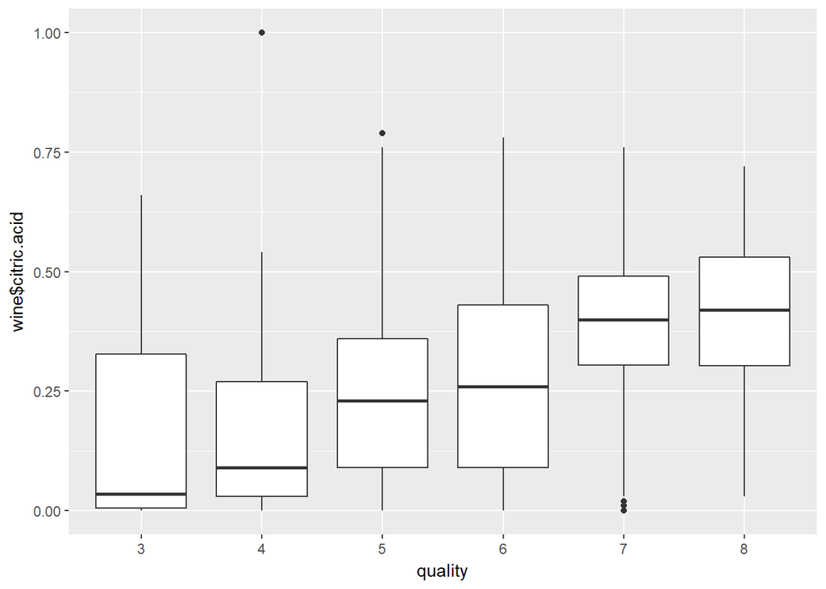

Citric acid “found in small quantities, citric acid can add ‘freshness’ and flavor to wines” (see reference 1).

Wines with higher values of citric acid seem to have better quality

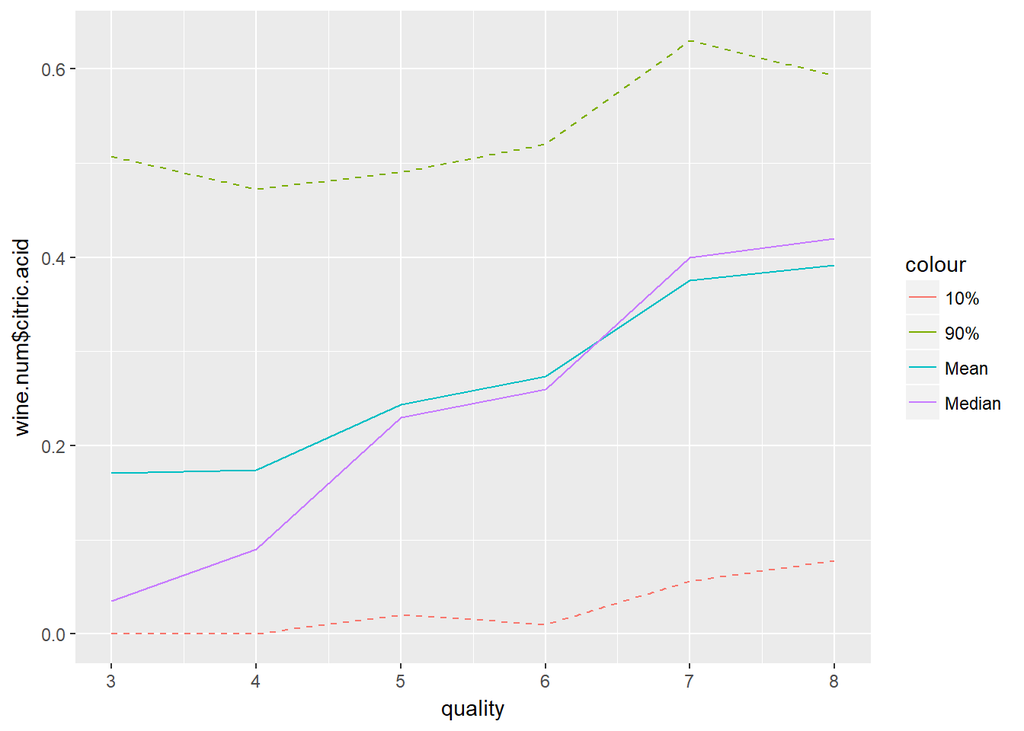

**Residual sugar**

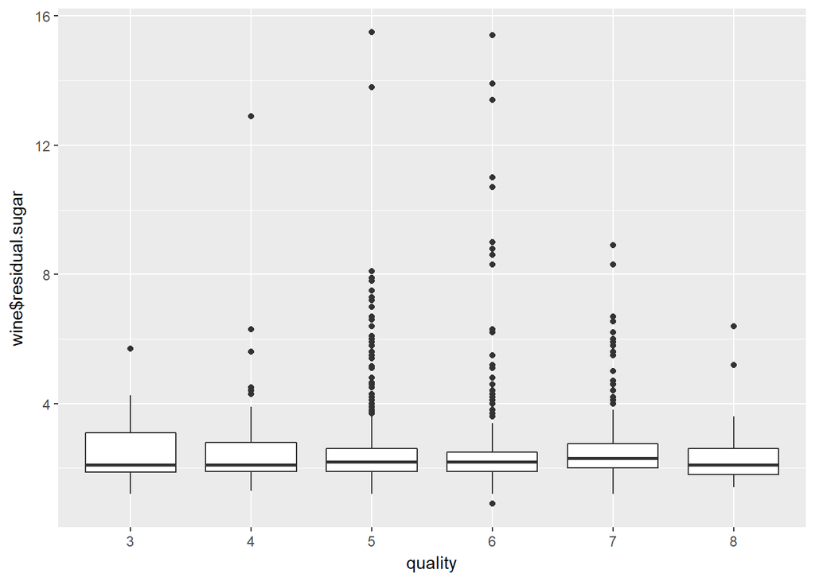

Residual sugar is “the amount of sugar remaining after fermentation stops, it’s rare to find wines with less than 1 gram/liter and wines with greater than 45 grams/liter are considered sweet”

All of the wines in this data set have the same median amount of sugar, which makes me think that this variable is not related to the quality of the wine. Also, there are several outliers in the data (wich correpond to the residual sugar histogram)

**Chlorides**

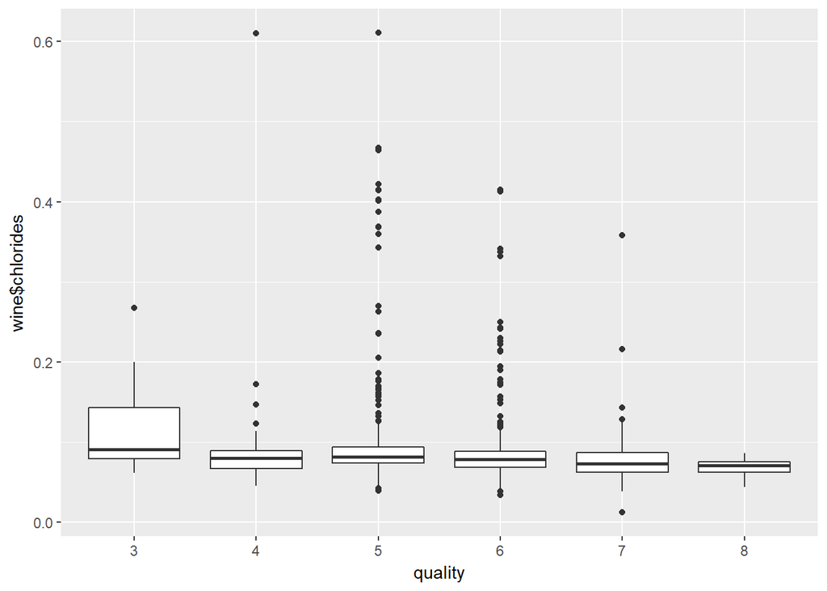

Chlorides refers to “the amount of salt in the wine” (see reference 1)

Same as with residual.sugar, all of the wines in this data set have the same median amount of chlorides, and there are several outliers in the data.

It is noticeable in the plot, that wines with quality of 8, have the lowest chlorides range of all the other wines so I can infere that good wines have a low amount of chlorides.

I want to see this relationship in another type of plot:

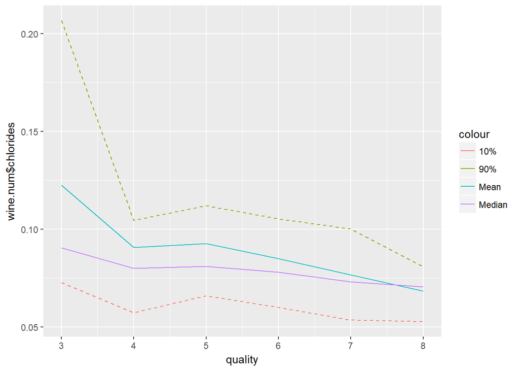

Here we can see better the disminution of chlorides range as the wine gets better. Now I’ll calculate the specific range:

```
## wine$quality: 3
## [1] 0.061 0.267
## --------------------------------------------------------
## wine$quality: 4
## [1] 0.045 0.610
## --------------------------------------------------------
## wine$quality: 5
## [1] 0.039 0.611
## --------------------------------------------------------
## wine$quality: 6
## [1] 0.034 0.415
## --------------------------------------------------------
## wine$quality: 7
## [1] 0.012 0.358
## --------------------------------------------------------
## wine$quality: 8
## [1] 0.044 0.086
```

**Free sulfur dioxide**

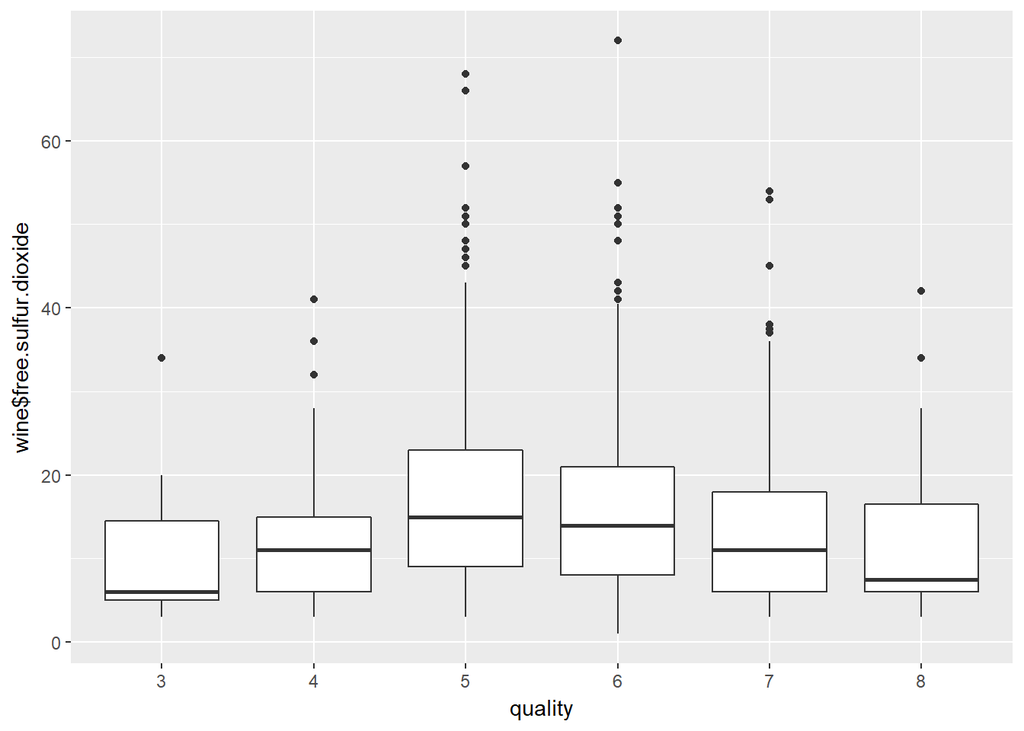

Free sulfur dioxide is “the free form of SO2 exists in equilibrium between molecular SO2 (as a dissolved gas) and bisulfite ion; it prevents microbial growth and the oxidation of wine” (see reference 1)

**Total sulfur dioxides**

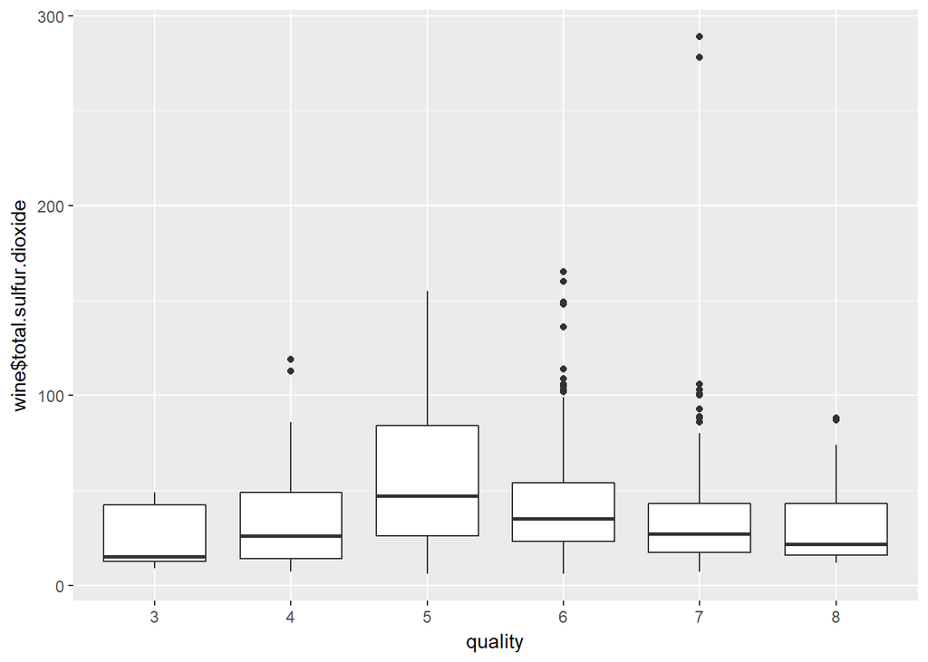

Total sulfur dioxide is “the amount of free and bound forms of S02; in low concentrations, SO2 is mostly undetectable in wine, but at free SO2 concentrations over 50 ppm, SO2 becomes evident in the nose and taste of wine” (see reference 1)

All of the wines of the worst quality have a total sulfur concentration of less than 50 ppm but also a significant amount of wines of 8 quality have less than 50 ppm, so I believe that this variable does not influence the quality of the wine.

**Density**

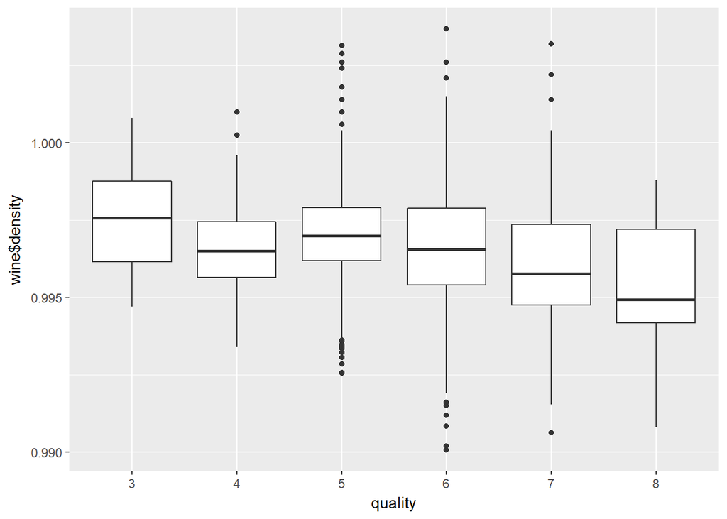

Density is “the density of water is close to that of water depending on the percent alcohol and sugar content” (see reference 1).

Wine’s density does not seem to be realted to its quality.

**pH**

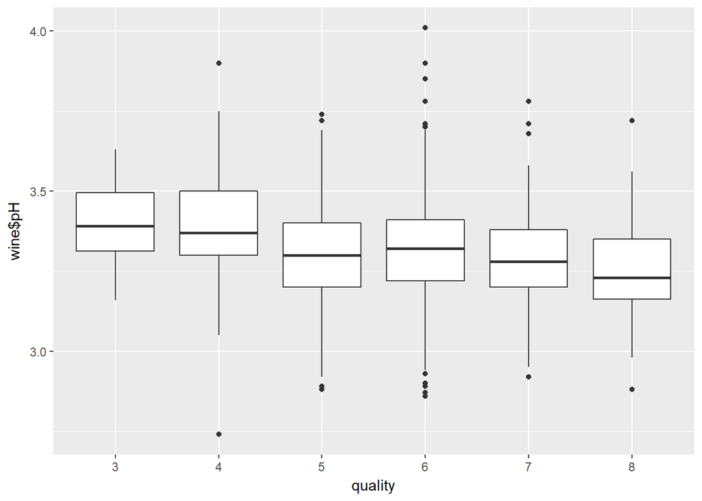

pH variable “describes how acidic or basic a wine is on a scale from 0 (very acidic) to 14 (very basic); most wines are between 3-4 on the pH scale” (see reference 1)

This variable does not seem to have a relationship with the wine’s quality.

**Sulphates**

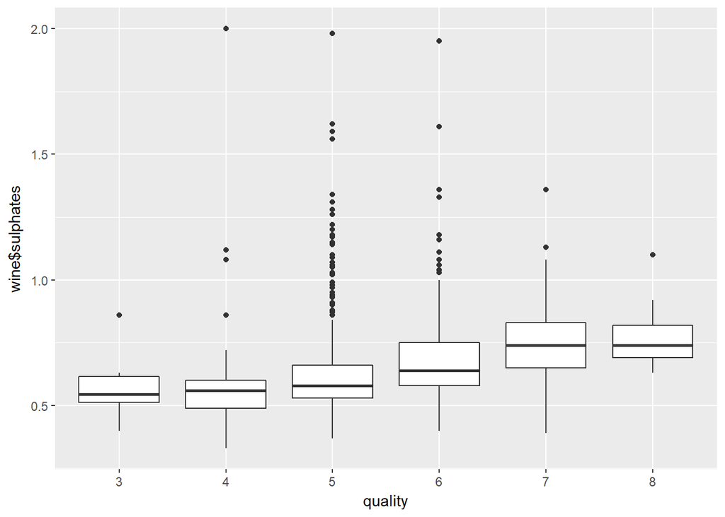

Sulphates are “a wine additive which can contribute to sulfur dioxide gas (S02) levels, wich acts as an antimicrobial and antioxidant” (see reference 1).

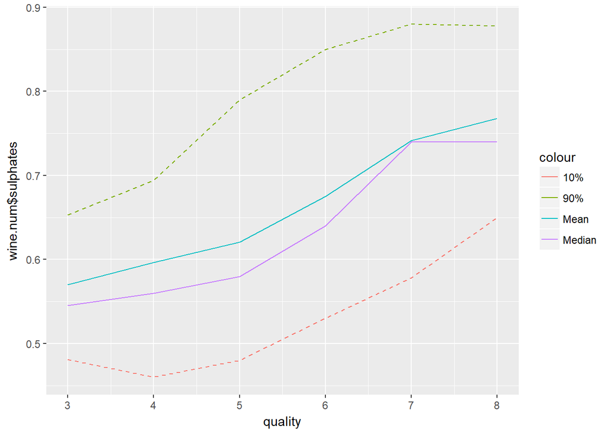

In the two plots above, we can see an increase in the median concentration as the quality of wine increases

**Alcohol**

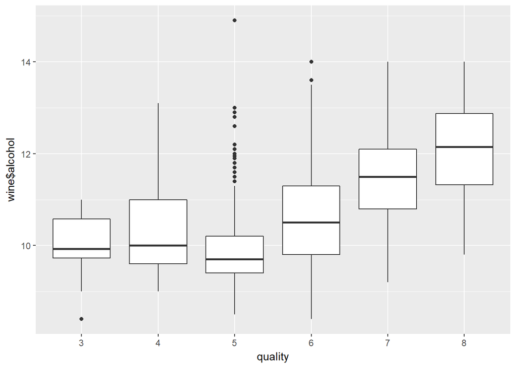

This variable refers to “the percent alcohol content of the wine” (see reference 1).

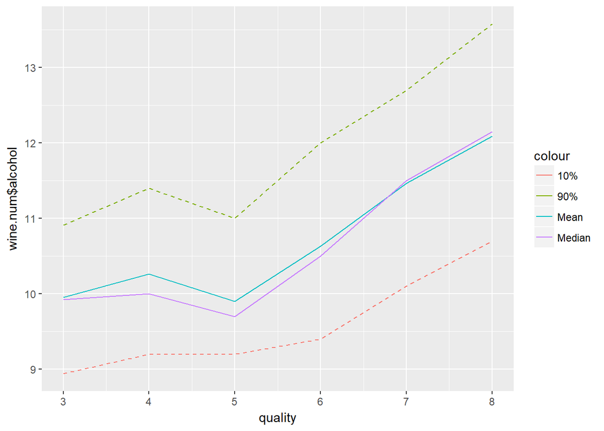

Wines of the best quality tend to have a higher alcohol level.